# Presentation

Hubert Nastały, Michał Milewski

spring 2020

# Introduction

… To display results related to specific bike station we always extract station name, longitude and latitude to bring them on the map respectively. Issues named *Workplaces*, *Spending free time* and *Hires by age* base on data gathered from six months (April-September) of 2019 (as Hubert has no disk space for more).

# Workplaces

We wanted to evaluate where the biggest workplaces are. To do that we take only hiring data with day from Monday to Friday and with morning hours (before 10). That info we extract from `stoptime`, so we assume people leave bikes by their offices as they go to work with this mean of transport. Finally, we group filtered data by each station and count total number of records and with distinction for men and women.

```r
workplaces <- function(DF){
  DF %>%
    mutate(weekday = format(as.Date(stoptime), "%u")) %>%
    filter(weekday >= 1 & weekday <= 5) %>%
    filter(hour(stoptime) < 10) %>%
    group_by(end.station.id) %>%
    summarise(end.station.name[1],
              end.station.latitude[1],
              end.station.longitude[1],
              hires = n(),
              manHires = sum(gender == 1),
              womanHires = sum(gender == 2)) %>%
    arrange(desc(hires)) -> Res

  colnames(Res) <- c("stationId", "stationName", "latitude",
                     "longitude", "totalHires", "manHires", "womanHires")
  return(Res)
}
```

# Workplaces - results

### Men and women

As we can see, vast majority of all bike returns happened in the middle of Manhattan and for one station in Jersey City. It looks quite reliably as there are a lot of offices in skyscrapers.

[interactive chart not shown]

### Men

[interactive chart not shown]

### Women

[interactive chart not shown]

### Comparison

Below we can see the layer of bike returns by men overlayed by women bike returns. This order is important because it turns out that most of returns is made by men.

[interactive chart not shown]

However, on some of the stations numbers of returns made by women are much higher than on others, so we can assume that near those stations may be placed workplaces that employ a lot of women.

[interactive chart not shown]

# Spending free time

In this issue we have tried to estimate locations that are chosen willingly by citizens to spend their free time. Thus, we filter only data with `stoptime` describing weekends and hours between 10 and 16. Eventually, we group data by station and count returns.

```r
spendingFreeTime <- function(DF){
  DF %>%
    filter(hour(stoptime) > 10 & hour(stoptime) < 16) %>%
    mutate(weekday = format(as.Date(stoptime), "%u")) %>%
    filter(weekday >= 6) %>%
    group_by(end.station.id) %>%
    summarise(end.station.name[1],
              end.station.latitude[1],
              end.station.longitude[1],
              hires = n()) -> Res

  colnames(Res) <- c("stationId", "stationName", "latitude", "longitude", "hires")
  return(Res)
}
```

# Spending free time - results

[interactive chart not shown]

Basing on the plot, people like to spend their weekend middays mostly in the Central Park and on the west coast of Manhattan. Also some others parks and squares are usually chosen as a destination. To make it clearer, only stations with return number greater than 5000 are presented below (marked with red spots).

[interactive chart not shown]

# Hires by age

The aim of this part of our analyzes is to check where people usually live according to their age. We extract data with hour in `starttime` column before 10, supposing that average bike rider take a bike in the morning to get to work. We grouped filtered results by station and count records for every of four age groups calculated using `birth.year` column: under 20, 20-39, 40-59 and 60-79.

```r
hiringByAge <- function(DF){
  currentYear <- as.integer(format(Sys.Date(), "%Y"))
  DF %>%
    filter(hour(starttime) < 10) %>%
    mutate(age = case_when(
      currentYear - birth.year < 20 ~ 20,
      currentYear - birth.year < 40 ~ 40,
      currentYear - birth.year < 60 ~ 60,
      currentYear - birth.year < 80 ~ 80,
      TRUE ~ 0
    )) %>%
    group_by(end.station.id) %>%
      summarise(end.station.name[1],
                end.station.latitude[1],
                end.station.longitude[1],
                under20 = sum(age == 20),
                under40 = sum(age == 40),
                under60 = sum(age == 60),
                under80 = sum(age == 80)) -> Res

  colnames(Res)[1:4] <- c("stationId", "stationName", "latitude", "longitude")
  return(Res)
}
```

# Hires by age - results

### Under 20

[interactive chart not shown]

The number of hires by this age group is not shocking. Young citizens do not prefer to ride bikes or there is no place for young people to live in the middle of New York. However, we can distinguish some light blue points that look interesting among the whole rest. On the map below they are painted red.

[interactive chart not shown]

When zooming in towards one of these red points, it turns out that they are situated near two high schools. Therefore, we did not find places where young people may live (except there are dormitories next to highschools), but it could mean that some students end classes or have longer break starting by 10.

### Between 20 and 40

[interactive chart not shown]

In this age category there are a lot of bike hires. However, we probably again missed the point of this issue. As most of the hires were made in the middle of Manhattan, it probably is not a proof that there live plenty of young adults. More appealing version is that stations with high hire rate are located near the communication nodes like subway stations, Grand Central Terminal or public carparks, where people can switch to bike when going to work.

[interactive chart not shown]

### Between 40 and 60

Results for this age group look pretty similar to previous group as both consist of citizens at working age. The new conclusion is that people from the former group ride bikes more often, but it should not be surprise.

[interactive chart not shown]

### Between 60 and 80

Elderly still ride by bike, but in much smaller numbers. And still results are similar to two previous groups. We have not succeeded in finding locations where each age group may live. However, we have localized strategic points for transport change, like subway, ferry and railway stations or big carparks.

[interactive chart not shown]

# Riders by Age and gender statistics

Here we want to analyse how does the different age groups ride their bikes. Which age group and gender rides most often? Which age group rides averagely the longest? Are there any differences between genders? Which age group rides actually the longest? Do the elderly people even ride the bikes? Do people after retirement age ride bikes more then people just before?

Data extraction: We only choose records where there is gender and birth year specified. For every record there is `AgeGroup` added. The age group is specified as such: 0-9 years old is 0’s, 10-19 years old is 10’s and so on. Then records are grouped by `ageGroup` and `gender`. For every group there is number of records counted, average trip duration, trips longer than 99% of the rest in group -this is called `Max` here. There is also 90th percentile computed so as to see if the max length of the most rides - maybe there are a lot of short rides and couple really long rides.

```r
ridersByAge <- function(DF){
  DF %>%
    filter(usertype == "Subscriber" & !is.na(as.integer(birth.year)) & gender != 0) %>%
    mutate(AgeGroup = plyr::round_any((2019 - as.integer(birth.year)),10,f = floor)) %>%
    filter(AgeGroup < 100) %>%
    group_by(AgeGroup, gender)%>%
    summarise(Count = n(),Mean = mean(tripduration), Median = median(tripduration), Max = quantile(tripduration,.99), percentile90th = quantile(tripduration,.90)) -> Res

  return(Res)
}
```

# Riders by Age and gender statistics - results

Fun fact is that people after 100 rides a bit more often than people just before 100 :) (actually not shown on this plots). To be frank, I think that this is just a error in data - probably people when registering choosen random number as theirs birth year. So in the folllowing plots there is no statistics for over 100 years old users

### Count of rides

Here we can see that majority of riders are men despite age group. The most active age group is 30’s. We can see that younger people rides definitelly more often. It is important to notice that the y-axis scale is logarithmic.

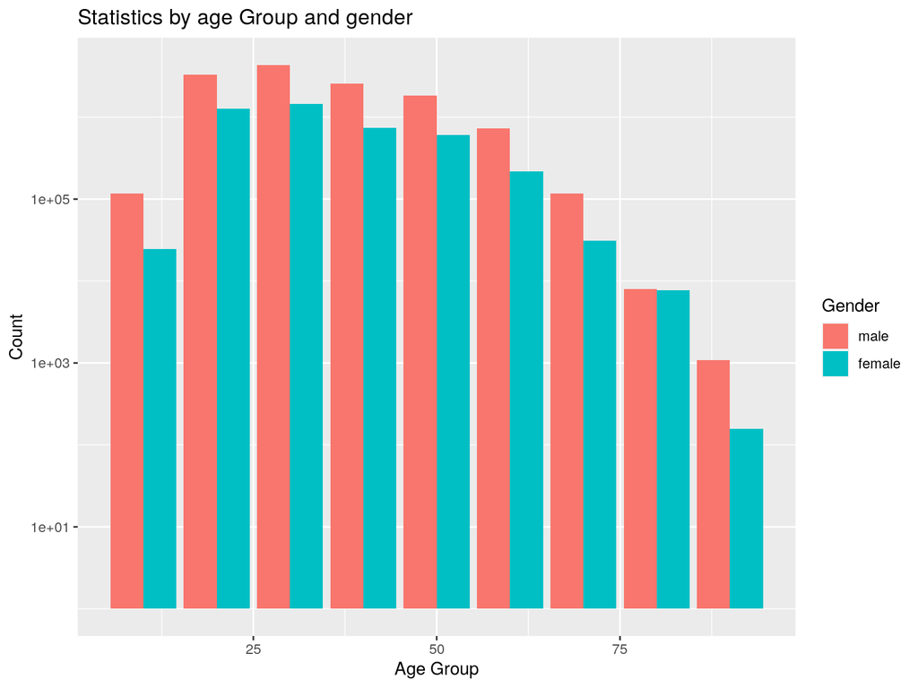

And this is the version with normal scales. Here it is better seen the difference between genders and ages.

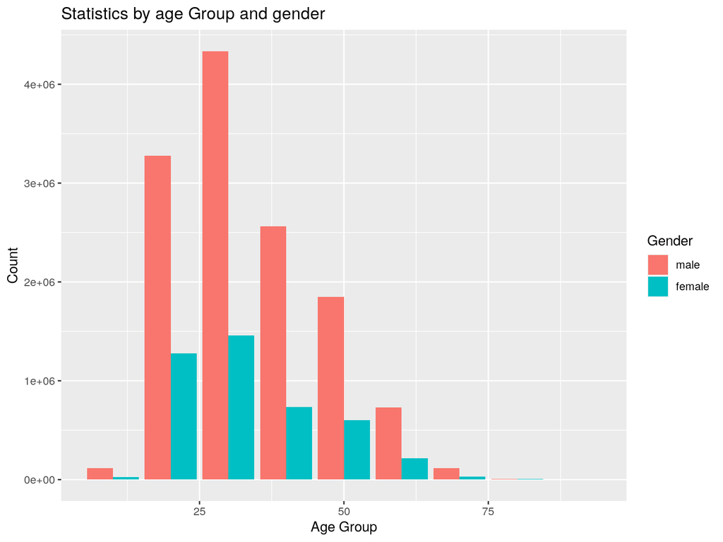

### Average trip duration

On this plot we can see that women rides averagedly longer than men. Most age groups have really close average trip duration time. Only really elderly people (90’s) rides a bit shorter. The women in their 80’s rides longer than ones other groups. Average trip duration is about 13-14 mins

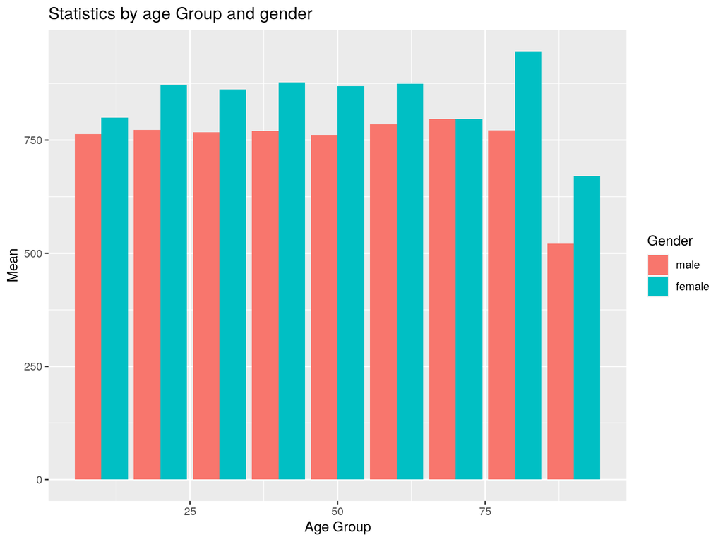

### Max of trip duration

In this statistics max is actually taken as a trip duration that is longer than 99% of whole trips. Don elike that so as to not show some data that are simple errors like not returned bike and so on.

Here we can see that women still rides longer than men. All of the groups have pretty the same max trip duration time. Only in 80’s there is high spike in women longest rides. Maybe thats results of really long riding grandma :). And in 10’s group males ride a bit longer than women. The difference is slight but it is possible to see that women in their 40’s rides the longest (not counting the super grandma). This results shows that people rides about 43 minutes max.

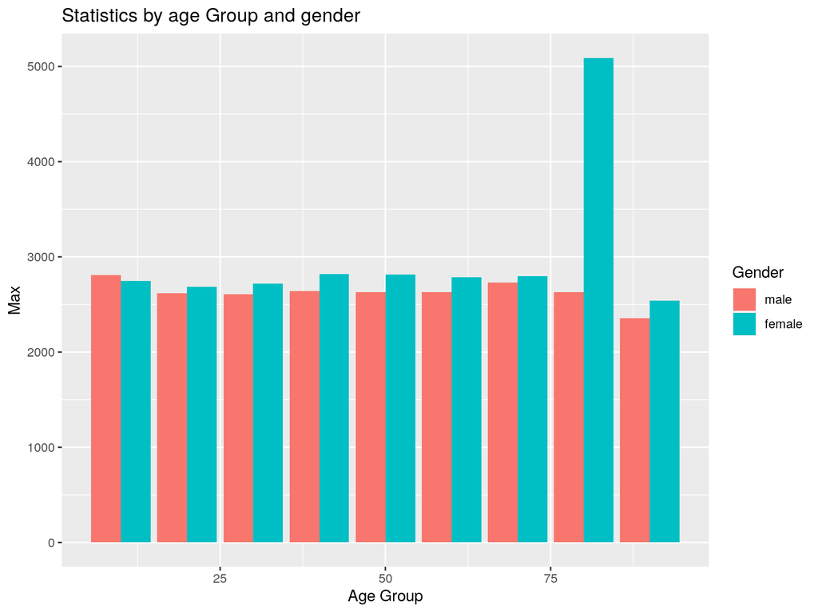

### Median of trip duration

Here is the same situation, women rides longer. For women it is about 10-11 mins and for mens it is about 8-9 mins.

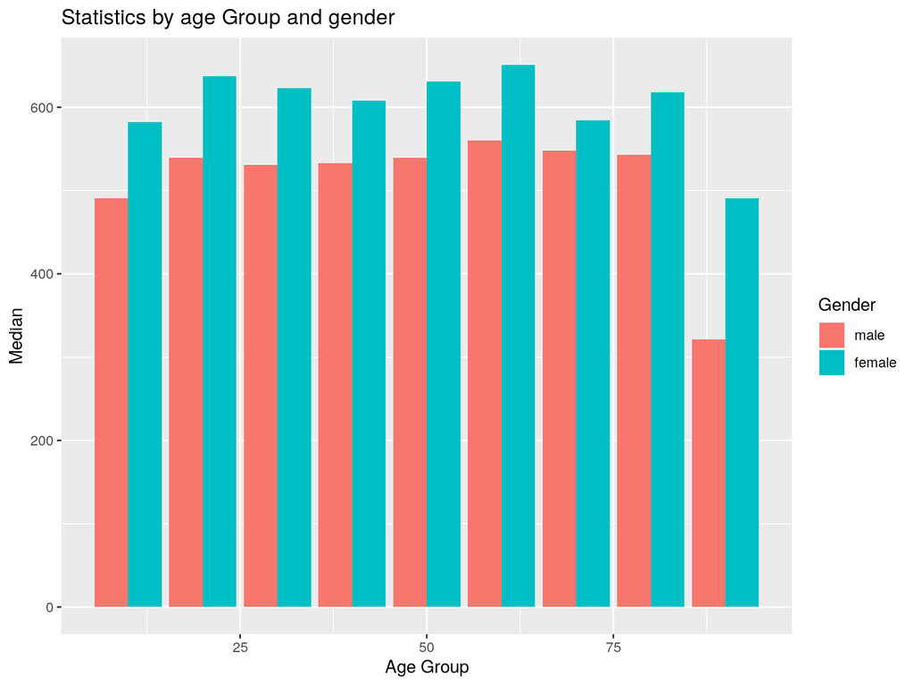

### 90th percentile of trip duration

Jus as i thought there are more shorter rides and couple long rides. 90 percent of rides are shorter than 25 mins for men and 27min for women

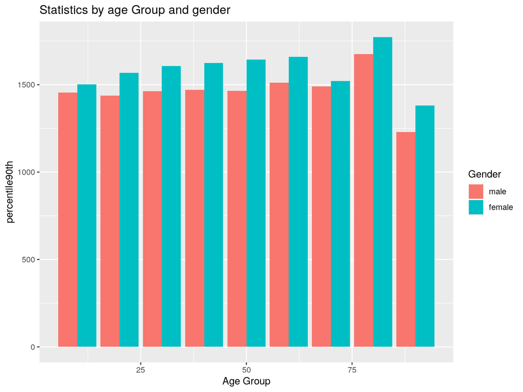

# When is the best time to ride? According to NYC riders

The purpose of this statistics was to found out whether there are some patterns houres at whitch people start their rides at different days. I hypothesised that from Monday to Friday more people ride bikes at the morning and in the evening. So let us found out what the results shown.

Data Extraction: Here we find at what time and at what day of week the ride was started. Then after grouping by weekday and time of the day, number of records was counted and average trip duration in each group was counted

```r
bestTimeToRide <- function(DF){
  DF %>%
    mutate(DayHour = hour(starttime))%>%
    mutate(weekday = as.numeric(format(as.Date(starttime), "%u"))) %>%
    group_by(weekday, DayHour)%>%
      summarise(Count = n(), Mean = mean(tripduration)) -> Res
  return(Res)
}
```

# The Results

### From Monday till Friday

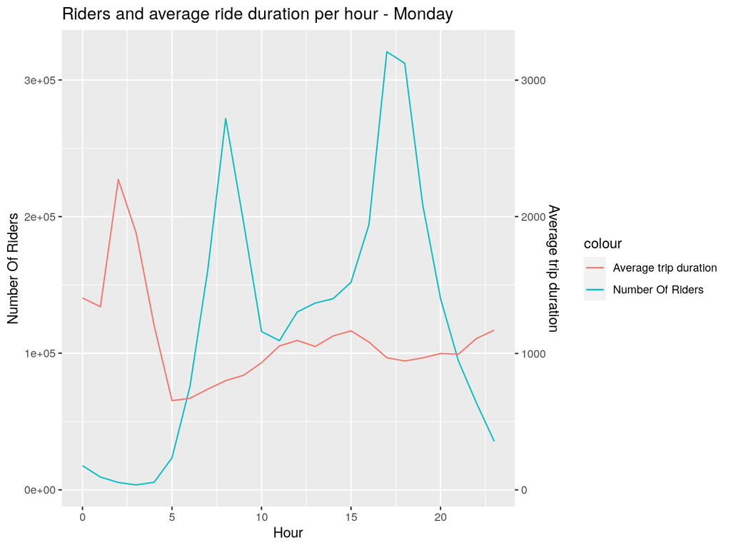

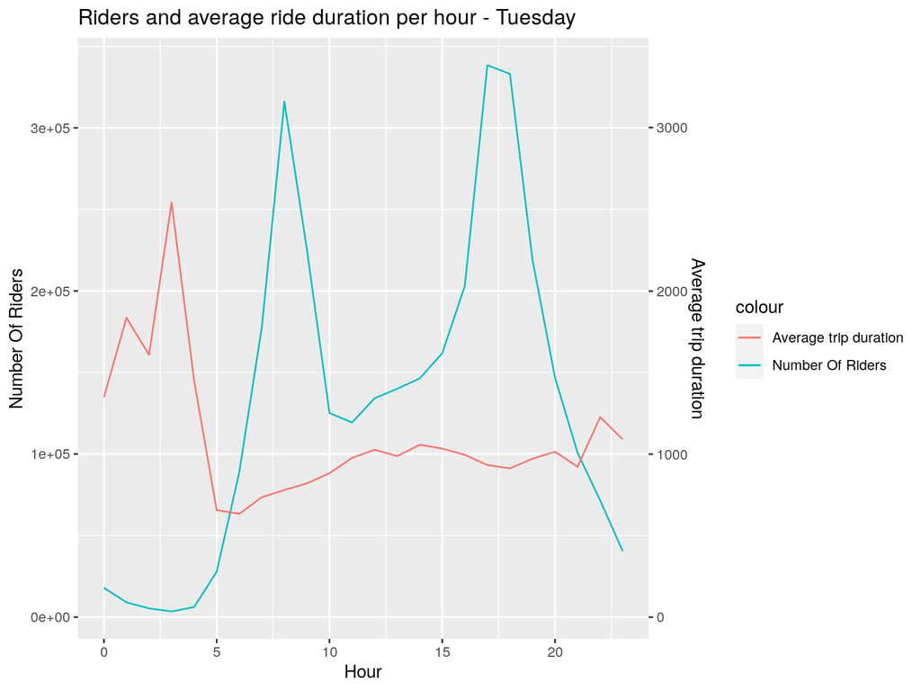

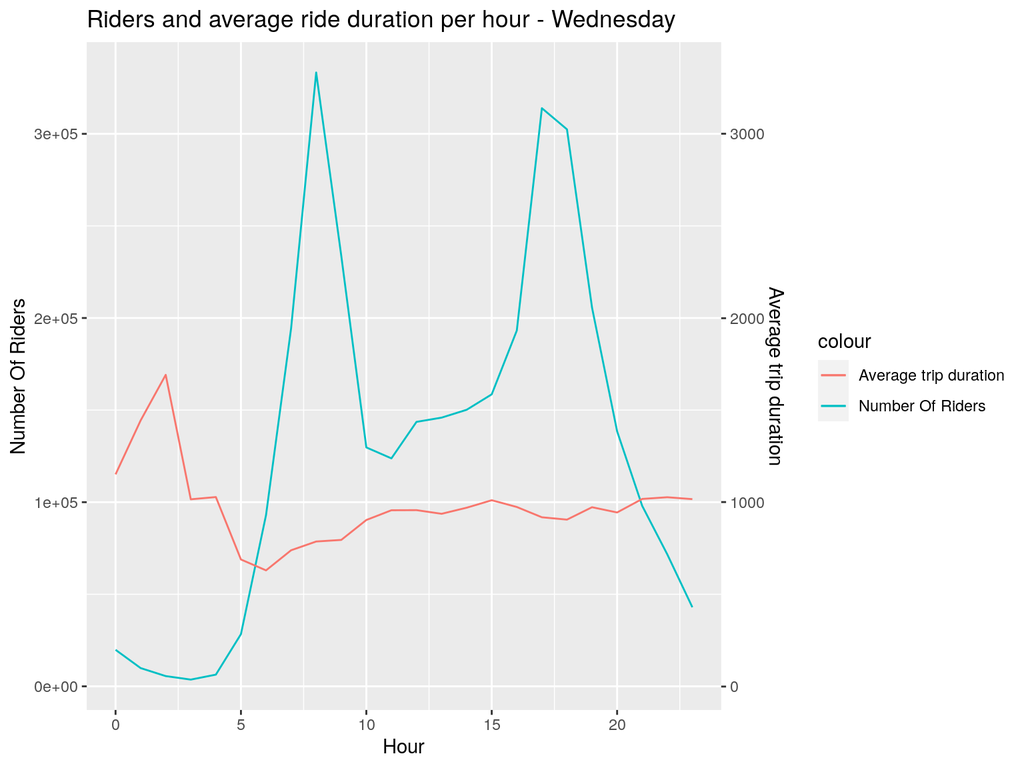

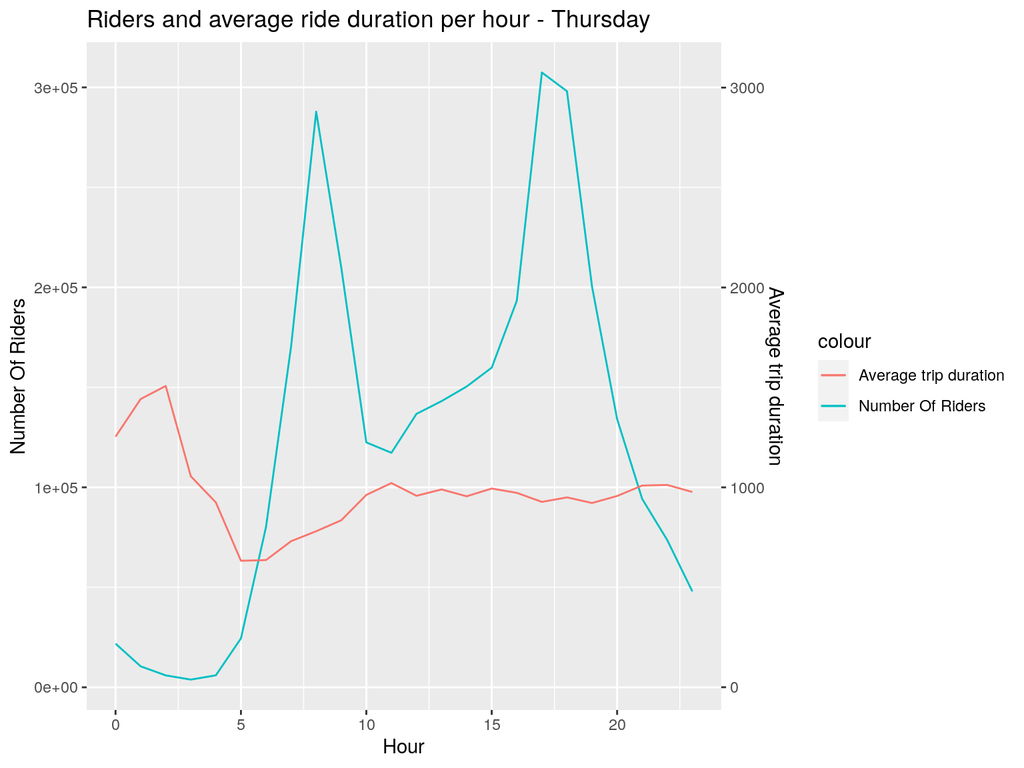

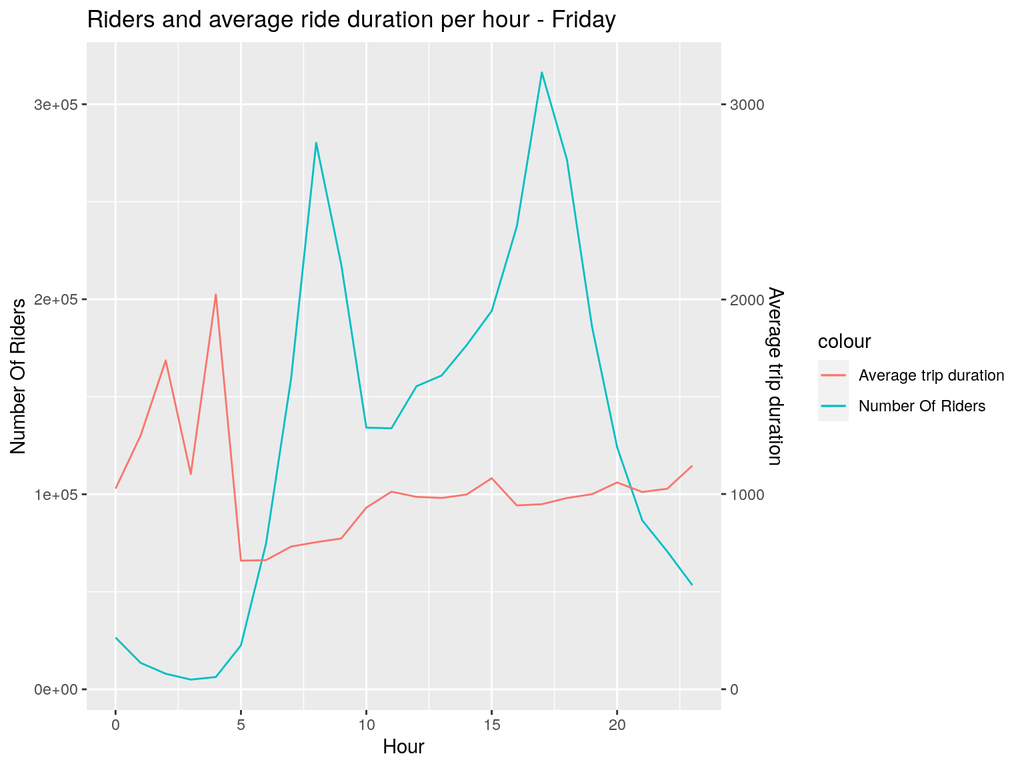

### Weekends

At weekends this plots looks more aestetically pleasing to my eye :). More people ride bikes in the middle of the day - from 10 till like 17. It is probably caused by people having free time and wanting to relaks a bit. Also the average ride time is a bit longer than in the working days, about 20 mins.

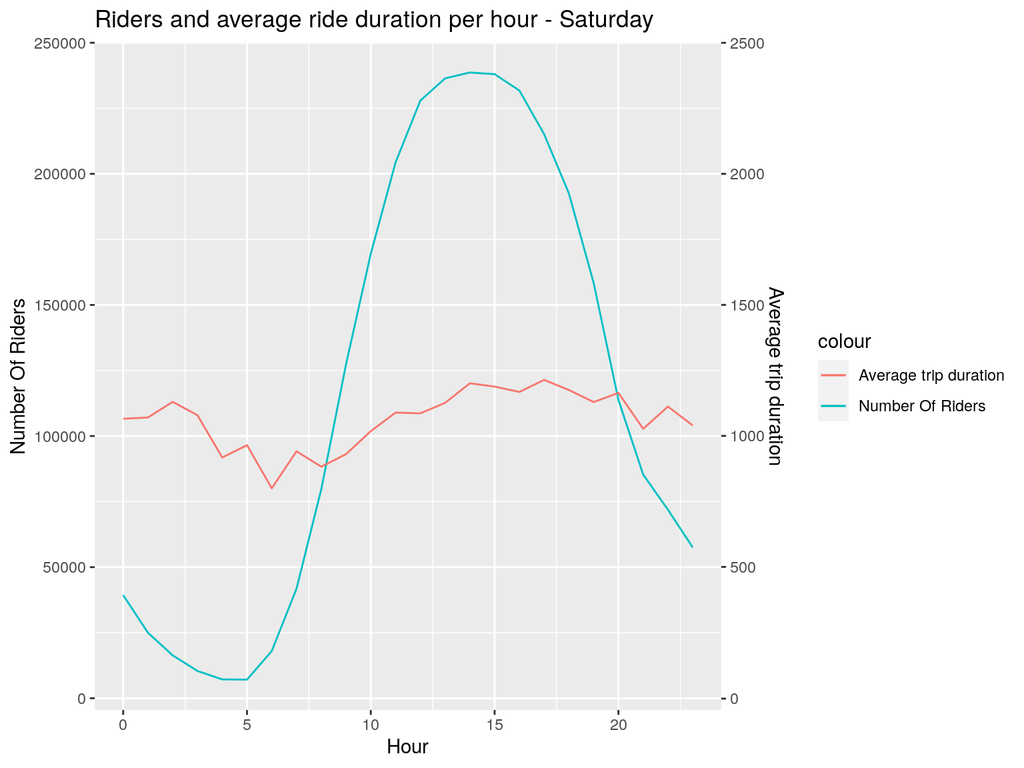

On Sunday a bit less people ride the bikes than on Saturday.

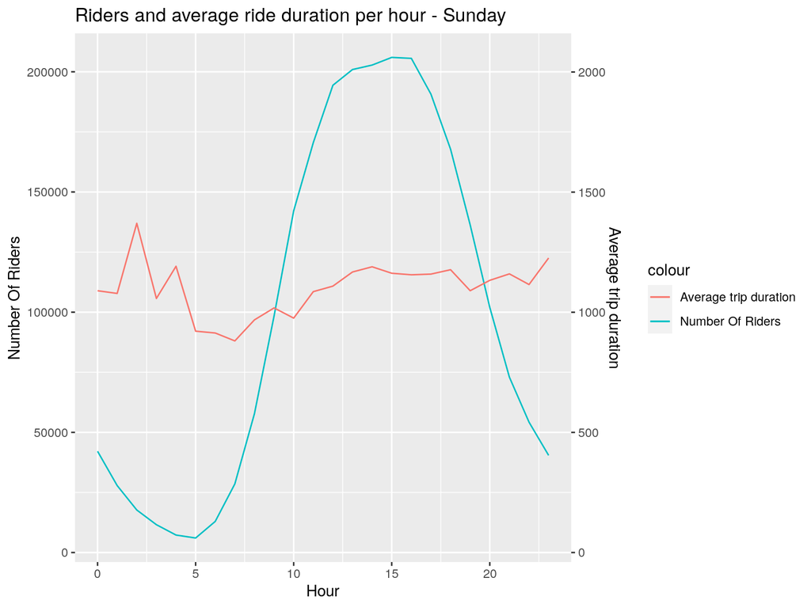

# When is the best time to ride but this time the longest? According to NYC riders

The purpose of this statistics was to show when people ride the longest trips.

Data Extraction: Here we find at what time and at what day of week the ride was started. Then after grouping by weekday and time of the day, number of records was counted and average trip duration in each group was counted. But only rides longer than 98 percent of other rides was taken under attention

```r
bestTimeToRideLong <- function(DF){
  highval = quantile(DF$tripduration,.98)
  DF %>%
    filter(tripduration >= highval) %>%
    mutate(DayHour = hour(starttime))%>%
    mutate(weekday = as.numeric(format(as.Date(starttime), "%u"))) %>%
    group_by(weekday, DayHour)%>%
    summarise(Count = n(), Mean = mean(tripduration)) -> Res
  return(Res)
}
```

# The Results

### From Monday till Friday

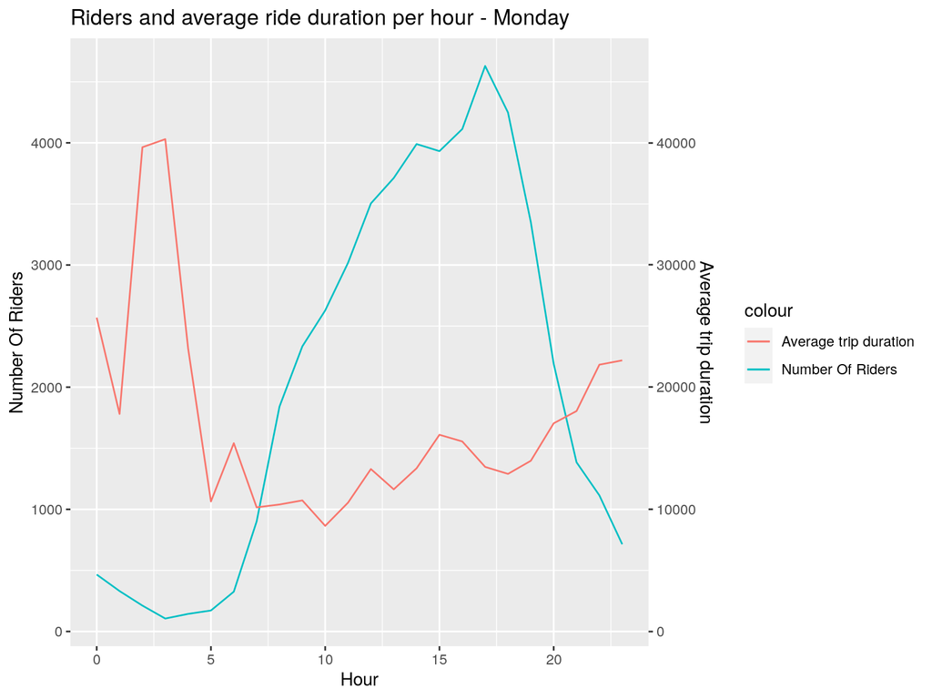

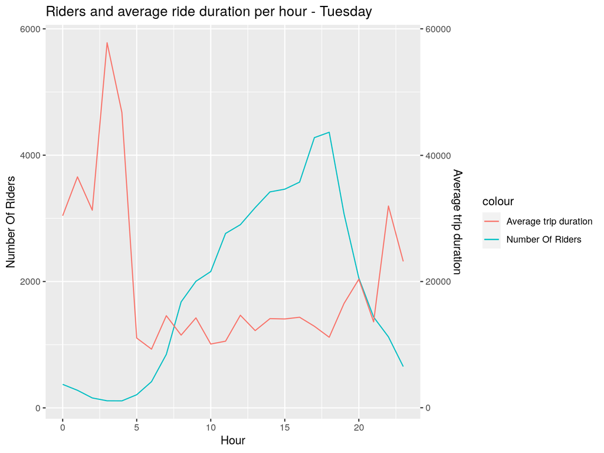

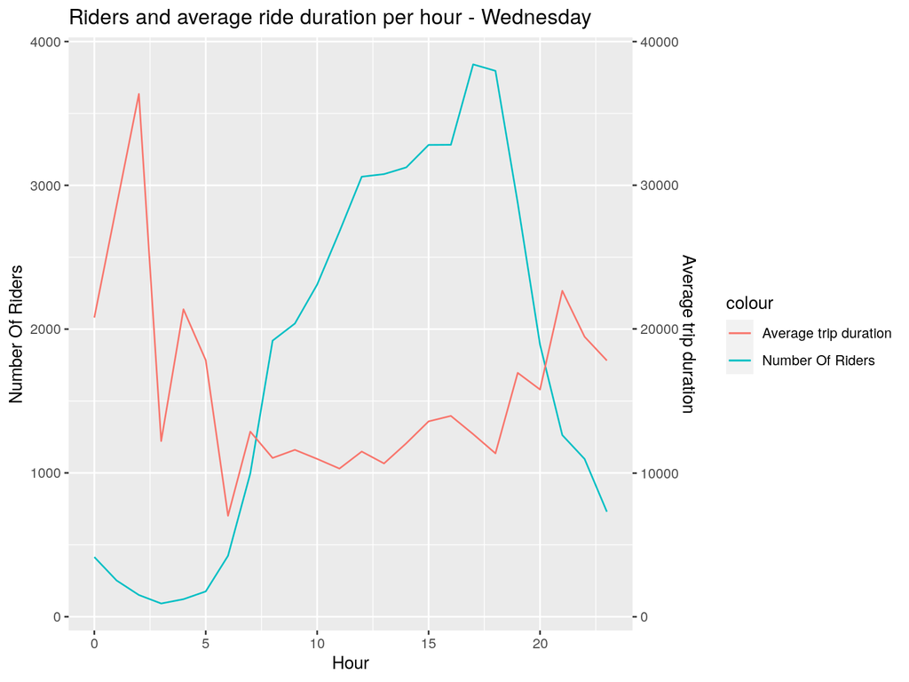

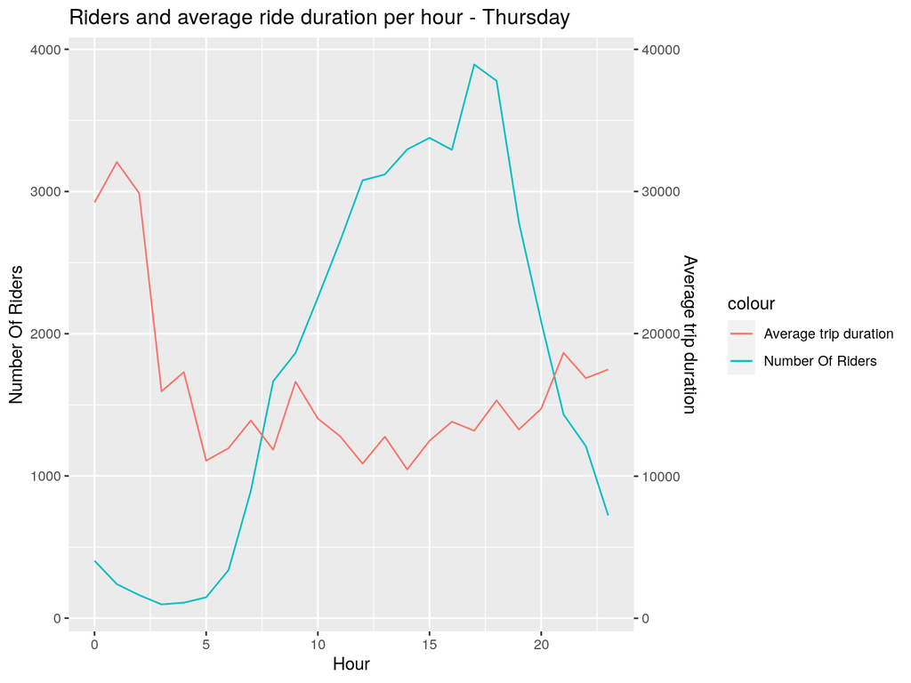

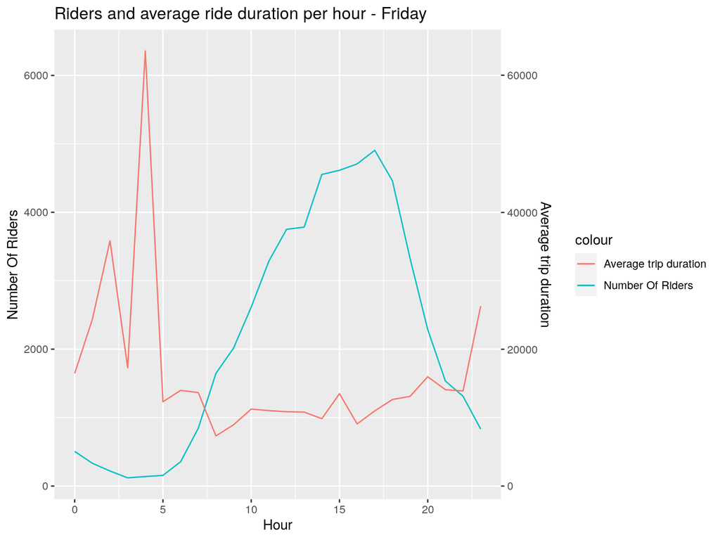

### Weekends

At weekend considerably more people ride the bikes the longest. The average trip time is pretty much comparable.

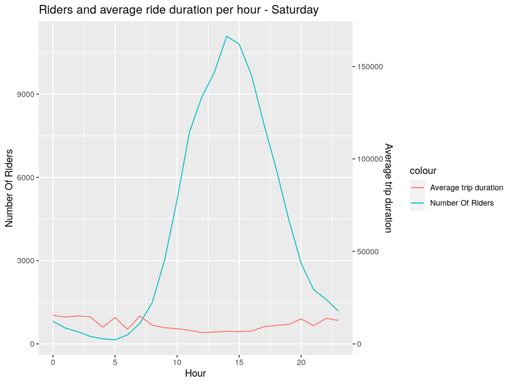

On Sunday a bit less people ride the bikes the longest than on Saturday.

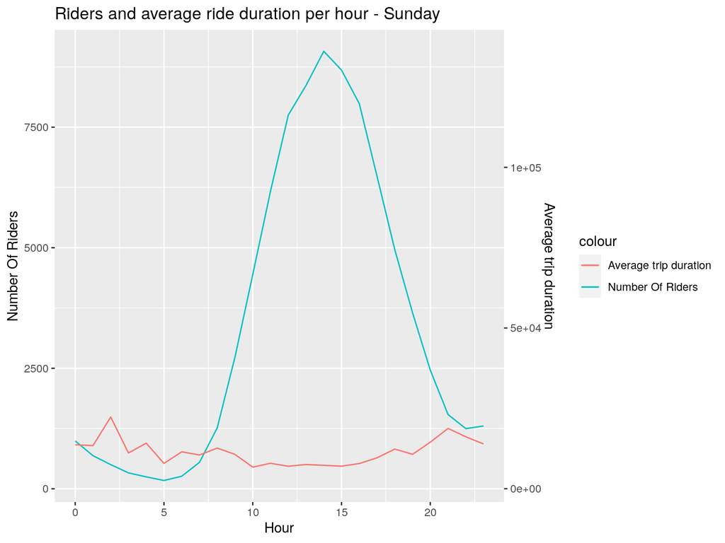

# Bonus - bikes top 10 :)

Purpose: Everybody likes rankings so why not do a bikes ranking? No deeper meaning, probably :)

Data Extraction: Data is grouped by `bikeid` then number of uses, summed time of usage and average usage time per use is extracted, simple.

```r
bikeRanking <- function(DF){
  DF %>%
    group_by(bikeid)%>%
    summarise(CountOfRenting = n(), SumOfRentedTime = sum(tripduration)) %>%
    mutate(AverageRentTime = SumOfRentedTime / CountOfRenting ) %>%
    arrange(desc(SumOfRentedTime)) -> Res
  return(Res)
}
```

# Rankings results

### Most often used bike

| bikeid | CountOfRenting | SumOfRentedTime | AverageRentTime |
| --- | --- | --- | --- |
| 35194 | 3150 | 2702561 | 857.9559 |
| 34332 | 3101 | 2595847 | 837.1000 |
| 34969 | 3097 | 2681726 | 865.9109 |
| 34187 | 3093 | 2566875 | 829.8982 |
| 34295 | 3064 | 3038230 | 991.5894 |
| 35226 | 3060 | 2518821 | 823.1441 |
| 33915 | 3031 | 2589996 | 854.5021 |
| 34059 | 3026 | 2577788 | 851.8797 |
| 35316 | 3021 | 2903870 | 961.2281 |
| 35115 | 3020 | 2728296 | 903.4093 |

### The longest used bike

| bikeid | CountOfRenting | SumOfRentedTime | AverageRentTime |
| --- | --- | --- | --- |
| 16498 | 908 | 5771695 | 6356.492 |
| 33682 | 540 | 5450729 | 10093.943 |
| 34851 | 1968 | 5418473 | 2753.289 |
| 32225 | 1438 | 5267583 | 3663.131 |
| 31052 | 1765 | 4818670 | 2730.125 |
| 31491 | 1356 | 4680938 | 3452.019 |
| 33922 | 2116 | 4634357 | 2190.150 |
| 32946 | 1431 | 4533288 | 3167.916 |
| 34398 | 2325 | 4531509 | 1949.036 |
| 35593 | 2346 | 4523795 | 1928.301 |

### The longest average use of the bike

| bikeid | CountOfRenting | SumOfRentedTime | AverageRentTime |
| --- | --- | --- | --- |
| 37947 | 2 | 2608974 | 1304487.00 |
| 37959 | 1 | 245254 | 245254.00 |
| 28660 | 42 | 4071599 | 96942.83 |
| 27128 | 176 | 2939320 | 16700.68 |
| 31347 | 4 | 65558 | 16389.50 |
| 30462 | 209 | 3116675 | 14912.32 |
| 30373 | 12 | 164362 | 13696.83 |
| 36980 | 71 | 898958 | 12661.38 |
| 14931 | 158 | 1929612 | 12212.73 |
| 25441 | 330 | 3894833 | 11802.52 |